# Mini-Project #04: Just the Fact(-Check)s, Ma’am!

Author

DavidZhai

# Task 1: Download CES Total Nonfarm Payroll

|  | date | level |
| --- | --- | --- |
| 1 | 1979-01-01 | 88808 |
| 2 | 1979-02-01 | 89055 |
| 3 | 1979-03-01 | 89479 |
| 4 | 1979-04-01 | 89417 |
| 5 | 1979-05-01 | 89789 |
| 6 | 1979-06-01 | 90108 |
| 7 | 1979-07-01 | 90217 |
| 8 | 1979-08-01 | 90300 |
| 9 | 1979-09-01 | 90327 |
| 10 | 1979-10-01 | 90481 |

[output cut: 548 more lines]

# Task 2: Download CES Revisions Tables

|  | date | original | final | revision |
| --- | --- | --- | --- | --- |
| 1 | 1979-01-01 | 325 | 243 | -82 |
| 2 | 1979-02-01 | 301 | 294 | -7 |
| 3 | 1979-03-01 | 324 | 445 | 121 |
| 4 | 1979-04-01 | 72 | -15 | -87 |
| 5 | 1979-05-01 | 171 | 291 | 120 |
| 6 | 1979-06-01 | 97 | 225 | 128 |
| 7 | 1979-07-01 | 44 | 87 | 43 |
| 8 | 1979-08-01 | 2 | 49 | 47 |
| 9 | 1979-09-01 | 135 | 41 | -94 |
| 10 | 1979-10-01 | 306 | 179 | -127 |

[output cut: 548 more lines]

|  | date | original | final | revision | level |
| --- | --- | --- | --- | --- | --- |
| 1 | 1979-01-01 | 325 | 243 | -82 | 88808 |
| 2 | 1979-02-01 | 301 | 294 | -7 | 89055 |
| 3 | 1979-03-01 | 324 | 445 | 121 | 89479 |
| 4 | 1979-04-01 | 72 | -15 | -87 | 89417 |
| 5 | 1979-05-01 | 171 | 291 | 120 | 89789 |
| 6 | 1979-06-01 | 97 | 225 | 128 | 90108 |
| 7 | 1979-07-01 | 44 | 87 | 43 | 90217 |
| 8 | 1979-08-01 | 2 | 49 | 47 | 90300 |
| 9 | 1979-09-01 | 135 | 41 | -94 | 90327 |
| 10 | 1979-10-01 | 306 | 179 | -127 | 90481 |

[output cut: 548 more lines]

# Task 3: Data Exploration and Visualization

|  | date | original | final | revision | level |
| --- | --- | --- | --- | --- | --- |
| 1 | 1979-01-01 | 325 | 243 | -82 | 88808 |
| 2 | 1979-02-01 | 301 | 294 | -7 | 89055 |
| 3 | 1979-03-01 | 324 | 445 | 121 | 89479 |
| 4 | 1979-04-01 | 72 | -15 | -87 | 89417 |
| 5 | 1979-05-01 | 171 | 291 | 120 | 89789 |
| 6 | 1979-06-01 | 97 | 225 | 128 | 90108 |
| 7 | 1979-07-01 | 44 | 87 | 43 | 90217 |
| 8 | 1979-08-01 | 2 | 49 | 47 | 90300 |
| 9 | 1979-09-01 | 135 | 41 | -94 | 90327 |
| 10 | 1979-10-01 | 306 | 179 | -127 | 90481 |

[output cut: 548 more lines]

Summary Statistics for CES Revisions (1979–2024)

| Metric | Value |
| --- | --- |
| Largest positive revision | 2021-11-01 (437) |
| Largest negative revision | 2020-03-01 (-672) |
| Mean absolute revision (units) | 56.9 |
| Median absolute revision as % of level | 0.0326% |
| Fraction of positive revisions overall | 0.57 |
| Year with highest mean relative revision | 1981 (0.8634) |

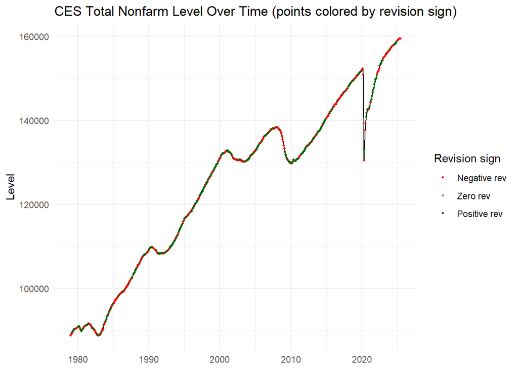

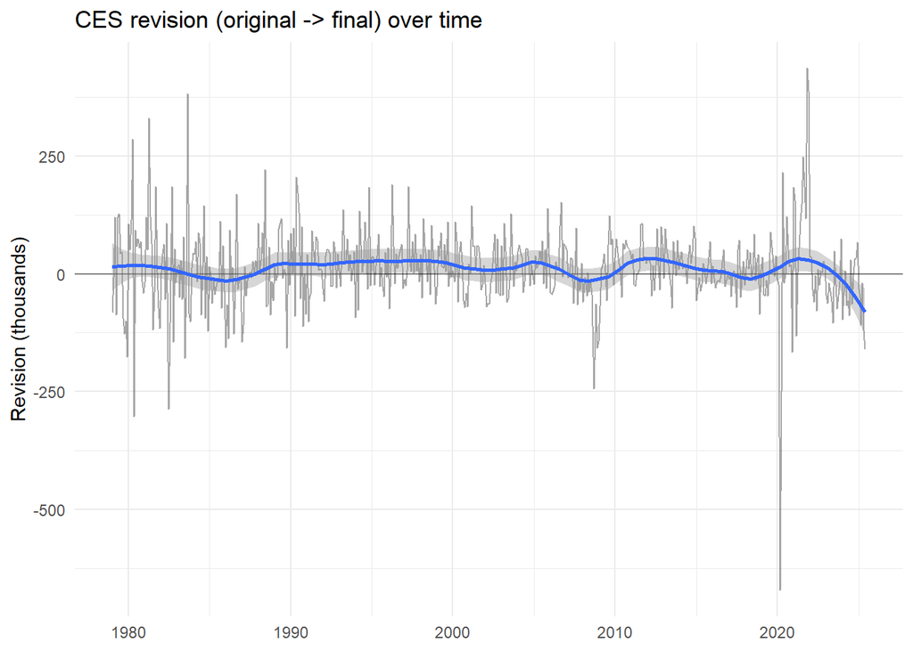

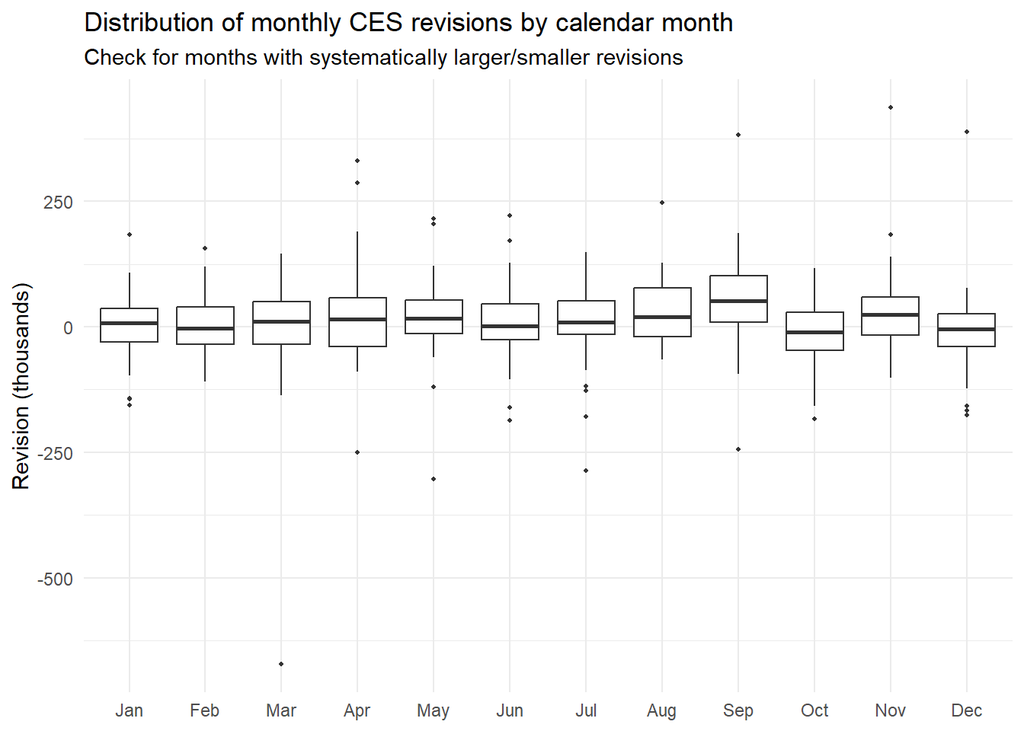

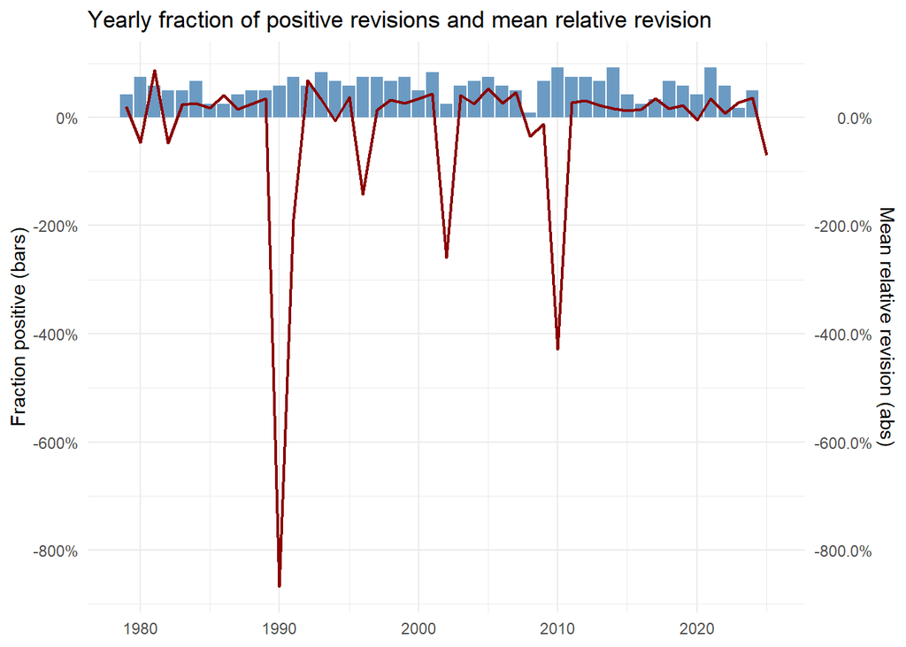

# Task 4: Statistical Inference

| Test | Statistic | P_value | Decision |
| --- | --- | --- | --- |
| Fraction of negative revisions ↑ post-2000? | 1.5364 | 0.2152 | Fail to Reject |
| Mean revision significantly ≠ 0? | 3.2594 | 0.001185 | Reject H0 |
| Mean revision ↑ post-2020? | 0.7025 | 0.4847 | Fail to Reject |

# Task 5: Fact Checks of Claims about BLS

## FACT CHECK 1 — Claim attributed to President Trump  
“Head of the Bureau of Labor Statistics did the same thing just before the Presidential Election, when she lifted the numbers for jobs to an all time high … I then won the Election, anyway, and she readjusted the numbers downward, calling it a mistake, of almost one million jobs. … faked the Jobs Numbers before the Election to try and boost Kamala’s chances of Victory.”  
Verdict: FALSE  
The data show routine monthly revisions that are small relative to the level of employment, no evidence of systematic, near-1-million job “lift” immediately before an election attributable to BLS revisions, and the largest single revision in your dataset is much smaller in context and occurred for pandemic reasons.  
Key evidence: Largest positive revision: +437 (thousands) on 2021-11-01.  
**Largest negative revision: −672 (thousands) on 2020-03-01 (pandemic shock month).**

Mean absolute revision (units): 56.9 (thousands).

Median absolute revision as % of level: 0.0326% (tiny relative to employment level).

Fraction of positive revisions overall: 0.57 (slightly more increases than decreases; not overwhelmingly biased one way).

These numbers show: (a) the biggest revisions are on the order of a few hundred thousand (pandemic-era outliers), not “almost one million” in a routine pre-election adjustment; (b) typical revisions are much smaller (mean absolute ≈ 57k); (c) revision magnitudes are small relative to the total employment level (median relative revision ≈ 0.03%).

Visual evidence  
**Time series of revisions: shows monthly revisions from 1979 → 2025 with a blue LOESS trend. It reveals relatively small variation most of the time, with large spikes around the 2020 pandemic.**

Hypothesis test(s) )

Mean revision ≠ 0? test: statistic = 3.2594, p = 0.001185 → Reject H0 (there is a small but statistically detectable nonzero mean revision).  
**Interpretation: there is a small average revision (statistically nonzero), but statistical significance does not imply large magnitude — see median relative revision ≈ 0.0326%.**

Fraction of negative revisions ↑ post-2000? statistic = 1.5364, p = 0.2152 → Fail to reject (no evidence of an increase in negative revisions after 2000).

Combining absolute levels + revisions  
**If “lifting the numbers to an all-time high so a candidate wins” were true we would expect:**

Large, systematic positive revisions immediately after an election month (hundreds of thousands to millions), and a sharp negative revision later that exactly undoes the pre-election lift.

In reality: (a) largest single positive revision is +437k (2021-11) — large but not near 1,000k and not tied to a routine pre-election pattern; (b) most revisions are ~57k in magnitude and are tiny relative to total employment; (c) the large negative −672k revision is pandemic related (Mar 2020) and not an election-timed hidden correction. The time series plot shows the pandemic as the standout event; no recurring pre-election spike pattern appears.

Conclusion & Rating rationale

The claim that BLS “lifted” jobs by ~1 million before an election and then “readjusted” them later is not supported. The revision magnitudes and the timing evidence contradict the claim.

Politifact-style rating: False (not “Pants on Fire” because this looks like a large factual error/exaggeration, not supported by the revision magnitudes or patterns).

## FACT CHECK 2 — Claim attributed to Daniel Koh (paraphrase you provided)

“Nobody is faking numbers. Revisions happen all the time.”  
**Verdict: MOSTLY TRUE.**

**Key evidence**

Fraction of positive revisions overall: 0.57 (revisions are roughly balanced; not systematic huge one-sided bias).

Mean absolute revision: 56.9 thousands (typical revision magnitude is modest)

Median absolute revision as % of level: 0.0326% (revisions are tiny relative to employment levels typically).

Year with highest mean relative revision: 1981 (0.8634) — shows isolated historical episodes where relative revisions were large, but these are rare.

Hypothesis test(s)

Mean revision ≠ 0? statistic = 3.2594, p = 0.001185 → Reject H0 (there is a statistically significant mean revision, but magnitude small). Interpretation: statistically detectable average revision does not imply malicious manipulation; routine sample and seasonal adjustments create small systematic differences between early and final estimates.

Mean revision ↑ post-2020? statistic = 0.7025, p = 0.4847 → Fail to reject (no evidence mean revisions rose after 2020 in a way that would indicate new systematic manipulation).

Fraction of negative revisions ↑ post-2000? p = 0.2152 → Fail to reject (no evidence of worsening negative bias after 2000).

Combining absolute levels + revisions

Conclusion & Rating rationale

The data support Koh’s claim that “revisions happen all the time” and that there’s no evidence of pervasive falsification in the CES revisions. The small average revision (statistically detectable) and a slightly >50% fraction of positive revisions do not show a pattern of politically timed manipulation.

Politifact-style rating: Mostly True (accurate characterization; acknowledges revisions are routine and not evidence of fraud).